# Extract raster values and find raster area by polygons

Alexander Sheludkov

31.01.2018

Here are some of my findings and observations. Hope, they would be helpful for someone. In turn, [the materials of gis.stackexchange](https://gis.stackexchange.com/questions/130522/increasing-speed-of-crop-mask-extract-raster-by-many-polygons-in-r) were of a big help for me.

## Task

So, our task is to find an area of land of different classes by polygons. We will follow this algorithm. For each polygon:

- extract raster values
- find the number of cells of different classes
- find a cell area and multiply by the number of cells.

Packages we need:

```r
library(sp)
library(raster)
library(rgdal)
require(velox)
require(tidyverse) # for table data manupulation and visualization
```

## 1. Example data

An example polygon layer represents municipal borders of Tyumen province of Russia, based on [OpenStreetMap](https://www.openstreetmap.org/) data.

```r
load("data/myPolygons.Rdata")
```

As for an example raster data, let’s generate a RasterLayer with random values

```r
set.seed(121)
# Create an "empty" RasterLayer object with extent and projection of our Spatial* object -->
r <- raster(ncol=1000, nrow=1000,
            ext = extent(myPolygons),
            crs = crs(myPolygons))
ncell(r) # number of cells
```

```
## [1] 1e+06
```

Assume, that we have 7 classes with 1-class as most rare and 7-class as mostly widespread. Assign random values to raster cells.

```r
values(r) <- sample(x = 1:7,
                    size = ncell(r), replace = T,
                    prob = seq(0.1, 0.7, 0.1))
```

Raster layer’s values distribution

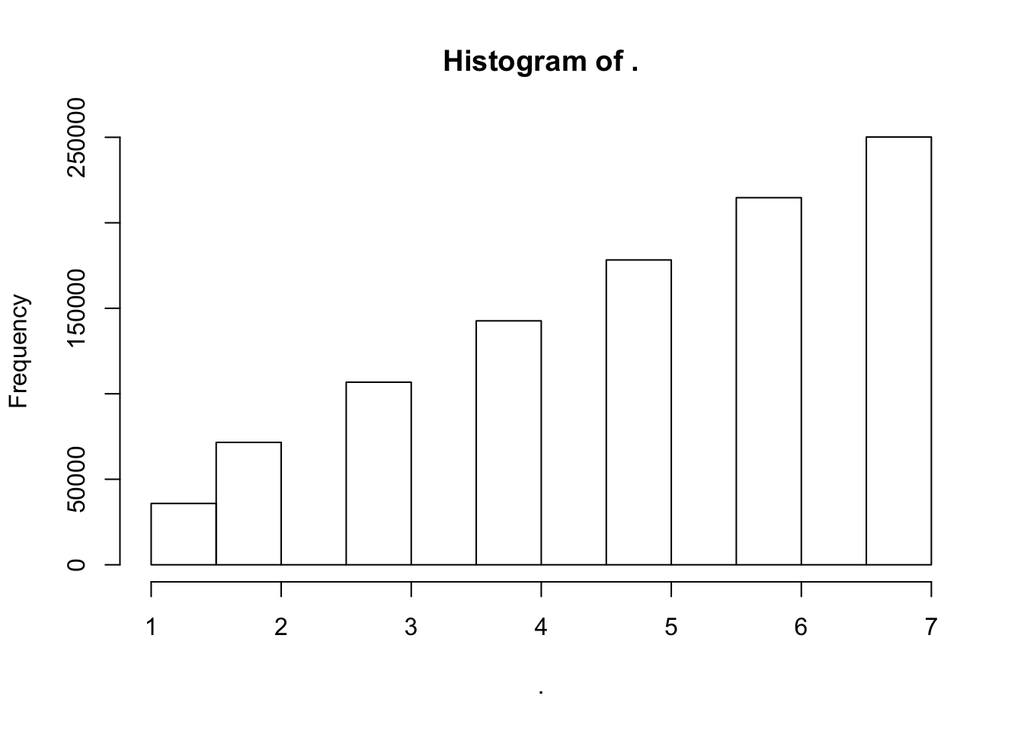

```r
values(r) %>% hist()
```

So, let’s take a look of our example data

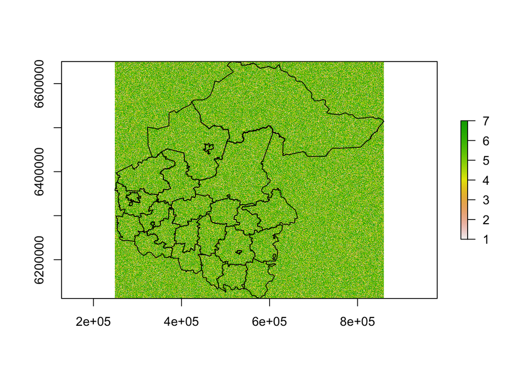

```r
plot(r)
plot(myPolygons, add = T)
```

## 2. Extracting raster values

Basic packages for spatial data manipulation and analysis in R are sp and raster. raster provides extract() and getValues() functions. We’ll try both.

### 2.1. raster::extract()

```r
system.time({
  raster:: extract(x = r, y = myPolygons, na.rm = T, df = T) %>% # Extract the values into data.frame
    group_by(ID, layer) %>%                                      # Group by spatial feature id and raster class
    summarise(n = n()) %>%                                       # For each sp feature calculate the number of cells of dif. classes
    spread(layer, n) -> test1                                    # Reshape the table
}) -> time1
```

Ok, the time we spent was:

```r
time1
```

```
##    user  system elapsed
##  27.321   0.530  27.957
```

And the resulting table:

```r
head(test1)
```

```
## # A tibble: 6 x 8
## # Groups:   ID [6]
##      ID   `1`   `2`   `3`   `4`   `5`   `6`   `7`
##   <dbl> <int> <int> <int> <int> <int> <int> <int>
## 1     1    64   110   143   247   289   327   398
## 2     2   309   693   957  1319  1639  1924  2313
## 3     3   285   610   881  1212  1503  1795  2137
## 4     4   418   888  1207  1626  2138  2487  3014
## 5     5   729  1426  2120  2976  3558  4318  5024
## 6     6   808  1620  2378  3163  3937  4702  5712
```

### 2.2. raster::crop() %>% raster::mask() %>% raster::getValues()

This time we use getValues(). That means before extracting the values, we have to crop the RaslerLayer by polygons. We’ll do it by two steps:

- crop() - returns raster clipped by Spatial* object’s extent
- mask() - returns raster, clipped by Spatial* object’s contour

```r
system.time({
  test2 <- data.frame()
  for(i in 1:nrow(myPolygons)) {
    single <- myPolygons[i, ]
    clip1 <- crop(r, extent(single))
    clip2 <- mask(clip1, single)
    getValues(clip2) %>% table() %>% data.frame() %>% spread(., ., Freq) %>% mutate(id = i) -> tempTable
    test2 <- bind_rows(test2, tempTable)
  }
}) -> time2
```

```r
time2
```

```
##    user  system elapsed
##  26.847   0.318  27.327
```

```r
head(test2)
```

```
##     1    2    3    4    5    6    7 id
## 1  64  110  143  247  289  327  398  1
## 2 309  693  957 1319 1639 1924 2313  2
## 3 285  610  881 1212 1503 1795 2137  3
## 4 418  888 1207 1626 2138 2487 3014  4
## 5 729 1426 2120 2976 3558 4318 5024  5
## 6 808 1620 2378 3163 3937 4702 5712  6
```

The results almost the same. However, with larger rasters the second approach shows better results.

Notice, while working with large objects, it is useful to put print(i) in the begining of the loop, which allows you to follow the progress, and Sys.sleep(1) to the end of the loop.

### 2.3. velox::extract()

The package has some specific characteristics, which distinguish it from classic R syntax.

- To work with raster data we have to turn it to VeloxRaster object by velox()
- very important: VeloxRaster objects are mutable
- all the manipulations with VeloxRaster are methods, which can be called through $. This way: VeloxRaster$method

Let’s do it:

```r
vx <- velox(r) # this can take some time
system.time({
  vx$extract(sp = myPolygons, df = T) %>%
    group_by(ID_sp, do.call..rbind...out.) %>% summarise(n = n()) %>%
    spread(do.call..rbind...out., n) -> test3
}) -> time3
```

```r
time3
```

```
##    user  system elapsed
##   9.388   0.157   9.649
```

```r
head(test3)
```

```
## # A tibble: 6 x 8
## # Groups:   ID_sp [6]
##    ID_sp   `1`   `2`   `3`   `4`   `5`   `6`   `7`
##   <fctr> <int> <int> <int> <int> <int> <int> <int>
## 1      0    64   110   143   247   289   327   398
## 2      1   309   693   957  1319  1639  1924  2313
## 3     10   321   610   918  1308  1498  1818  2119
## 4     11   570  1163  1901  2486  3143  3868  4416
## 5     12   592  1223  1813  2321  2970  3633  4106
## 6     13   359   716   987  1342  1629  1961  2340
```

Wow. Don’t know, how they do it, but that was much faster.

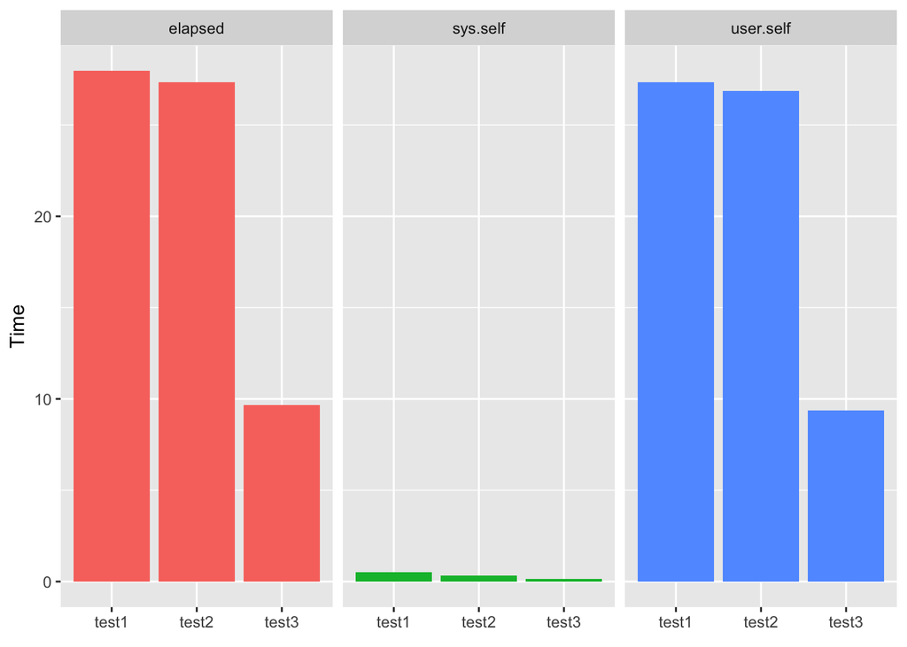

In my case I revealed that cropping raster layer before extracting the values was the best strategy. So, the final code was:

```r
vx <- velox(r)
result <- data.frame()
for(i in 1:nrow(myPolygons)) {
  print(i)
  single <- myPolygons[i, ]
  vx_copy <- vx$copy()
  vx_copy$crop(single)
  vals <- vx_copy$extract(single, df = T)
  # If polygon does not cover raster layer, extract() returns empty list, otherwise data.frame
  if (is.data.frame(vals)) {
    vals %>%
      group_by(ID_sp, vals[,2]) %>% summarise(n = n()) %>%
      spread('vals[, 2]', n) -> tempTable
    tempTable <- cbind(single@data[1,1], tempTable[,-1])
    result <- bind_rows(result, tempTable)
  }
  Sys.sleep(1)
}
```

## 3. Calculating an area

Cell area in hectares (ha)

```r
cellArea <- res(r)[1] * res(r)[2] / 10000
```

Some data format cleaning

```r
test3$ID_sp <- as.character(test3$ID_sp) %>% as.integer(test3$ID_sp) # change data type
test3 %>% arrange(ID_sp) -> test3                                    # fix the order
```

Final calculations

```r
cbind(name = myPolygons@data[,1], test3[2:8] * cellArea) -> result
head(result)
```

```
##                     name         1         2         3          4
## 1 городской округ Тюмень  2106.062  3619.795  4705.733   8128.085
## 2       Упоровский район 10168.333 22804.708 31492.215  43404.631
## 3         Исетский район  9378.559 20073.408 28991.266  39883.558
## 4        Тюменский район 13755.220 29221.617 39719.022  53507.149
## 5        Ярковский район 23989.368 46925.704 69763.319  97931.904
## 6  Нижнетавдинский район 26589.039 53309.706 78253.383 104085.556
##            5         6         7
## 1   9510.188  10760.66  13097.08
## 2  53934.943  63313.50  76114.41
## 3  49459.561  59068.47  70322.74
## 4  70355.649  81840.27  99182.38
## 5 117083.910 142093.40 165325.90
## 6 129555.749 154729.78 187966.07
```

© Alexander Sheludkov. 2018. [Source code](https://github.com/alschel/extract-raster-values-r-tutorial/)